# Airline On-Time Performance

## by Hani Salah

## Investigation Overview

This presentation is intended to visually describe the main findings of USA Airline On-Time Performance.

## Dataset Overview

1. This data consists of flight arrival and departure details for all commercial flights within the USA, from October 1987 to April 2008. This is a large dataset: there are **nearly 120 million records** in total, and takes up 1.6 gigabytes of space compressed and 12 gigabytes when uncompressed.
2. Should all data be examined, tools other than **pandas** will be required (e.g. **dask**) to be able to wrangle *12GB* worth of data. For the sake of simplicity **years 1990, 1995, 2000, 2005 will be the only ones considered with 23.4 Million records.**

### **Departure Delay** Distribution

1. The distribution of delays is around the 'No significant delay point'.
2. The main spread of the departure delays is from -20 minutes (early departures) to 40 minutes.

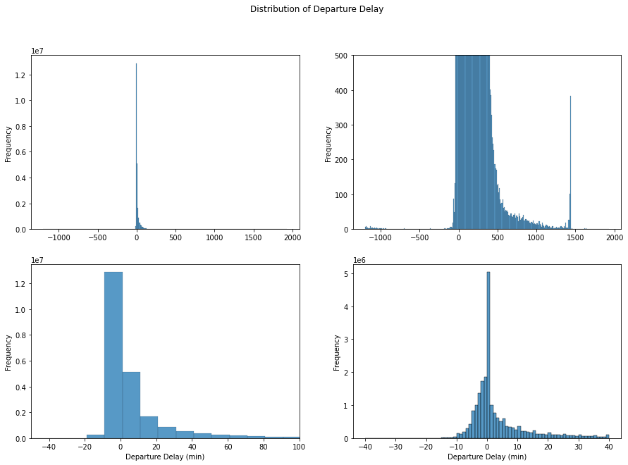

```python
plt.figure(figsize=(15,10))
plt.suptitle('Distribution of Departure Delay')
bins=np.arange(df['DepDelay'].min(),df['DepDelay'].max()+10,10)
bins_zoomed=np.arange(-40,40+1,1)

plt.subplot(2,2,1)
sb.histplot(data=df, x='DepDelay', bins=bins)
plt.ylabel('Frequency')
plt.xlabel('')

plt.subplot(2,2,2)
sb.histplot(data=df, x='DepDelay', bins=bins)
plt.ylim(0,500)
plt.ylabel('Frequency')
plt.xlabel('')

plt.subplot(2,2,3)
sb.histplot(data=df, x='DepDelay', bins=bins)
plt.xlim(-50,100)
plt.ylabel('Frequency')
plt.xlabel('Departure Delay (min)')

plt.subplot(2,2,4)
sb.histplot(data=df, x='DepDelay', bins=bins_zoomed)
plt.ylabel('Frequency')
plt.xlabel('Departure Delay (min)');
```

### **Arrival Delay** Distribution:

1. The distribution of delays is around the 'No significant delay point'.
2. The main spread of the arrival delays is from -20 minutes (early arrivals) to 60 minutes.

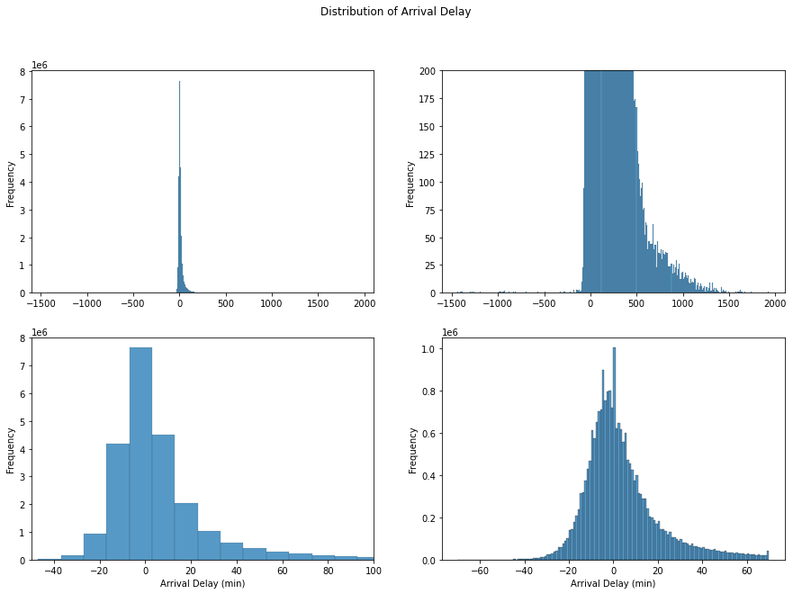

```python
plt.figure(figsize=(15,10))
plt.suptitle('Distribution of Arrival Delay')
bins=np.arange(df['ArrDelay'].min(),df['ArrDelay'].max()+10,10)
bins_zoomed=np.arange(-70,70+1,1)

plt.subplot(2,2,1)
sb.histplot(data=df, x='ArrDelay', bins=bins)
plt.ylabel('Frequency')
plt.xlabel('')

plt.subplot(2,2,2)
sb.histplot(data=df, x='ArrDelay', bins=bins)
plt.ylim(0,200)
plt.ylabel('Frequency')
plt.xlabel('')

plt.subplot(2,2,3)
sb.histplot(data=df, x='ArrDelay', bins=bins)
plt.xlim(-50,100)
plt.ylabel('Frequency')
plt.xlabel('Arrival Delay (min)')

plt.subplot(2,2,4)
sb.histplot(data=df, x='ArrDelay', bins=bins_zoomed)
plt.ylabel('Frequency')
plt.xlabel('Arrival Delay (min)');
```

### Flight Times Distribution:

The distribution of flights timing (both Departure and Arrival) doesnot reveal much except that the US skies is busy starting 6:00 up to 20:00 ~ 22:00

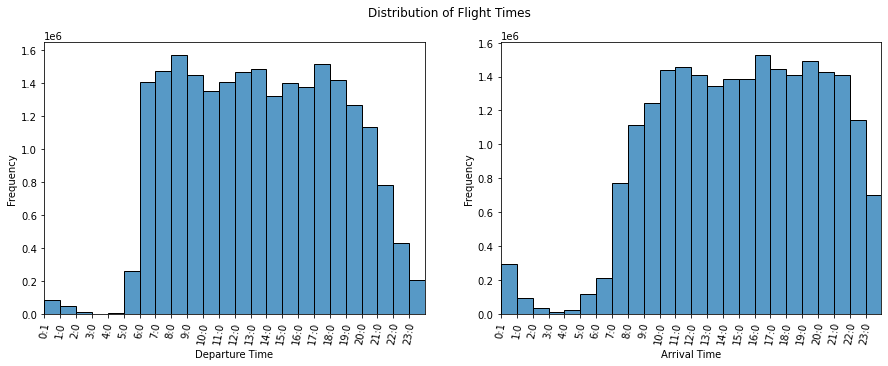

```python
plt.figure(figsize=(15,5))
plt.suptitle('Distribution of Flight Times')

plt.subplot(1,2,1)
bins=np.arange(df['DepTime'].min(),df['DepTime'].max()+1,1)
sb.histplot(data=df, x='DepTime', bins=bins)
plt.ylabel('Frequency')
labels= np.char.add( (bins//1).astype(int).astype(str), np.char.add(':', ((bins%1)*60).astype(int).astype(str) )).tolist()
plt.xticks(bins, labels, rotation=80)
plt.xlim(0,24)
plt.xlabel('Departure Time')

plt.subplot(1,2,2)
bins=np.arange(df['ArrTime'].min(),df['ArrTime'].max()+1,1)
sb.histplot(data=df, x='ArrTime', bins=bins)
plt.ylabel('Frequency')
labels= np.char.add( (bins//1).astype(int).astype(str), np.char.add(':', ((bins%1)*60).astype(int).astype(str) )).tolist()
plt.xticks(bins, labels, rotation=80)
plt.xlim(0,24)
plt.xlabel('Arrival Time');
```

### Carrier Distribution:

We have 7 Carriers that each operated more than 1.5 million flights. We can call those the big players and have them further analyzed in bi/multi-variate analysis.

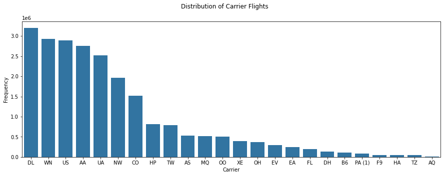

```python
base_color = sb.color_palette()[0]
plt.figure(figsize=(15,5))
plt.suptitle('Distribution of Carrier Flights')
sb.countplot(data=df, x='UniqueCarrier', color=base_color, order=df['UniqueCarrier'].value_counts().index)
plt.ylabel('Frequency')
plt.xlabel('Carrier');
```

### Busily Airports:

There are 11 airports that have more than 1 million flights each as shown in the zoomed view below

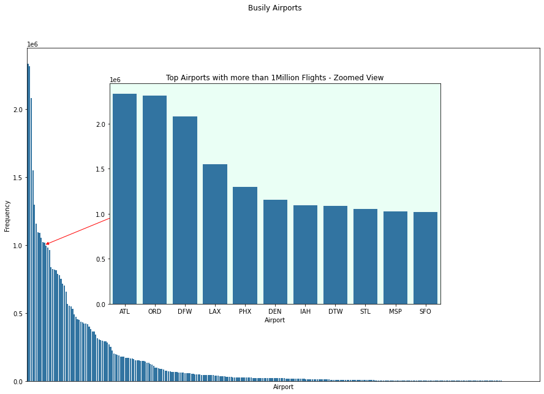

```python
base_color = sb.color_palette()[0]
flights_airports=df.melt(value_vars=['Origin','Dest'],var_name='Direction',value_name='Airport')
plt.figure(figsize=(15,10))
plt.suptitle('Busily Airports')

sb.countplot(data=flights_airports, x='Airport',order=flights_airports['Airport'].value_counts().index, color=base_color)
plt.ylabel('Frequency')
plt.xticks([])

zoom_df = flights_airports[flights_airports.groupby('Airport')['Airport'].transform('size')>=int(1e6)]
plt.annotate("", xy=(10, 1e6), xytext=(50, 1.2e6),arrowprops=dict(arrowstyle="-|>",color='r',ls='-'))
ax=plt.axes([0.25,0.3,0.5,0.5], facecolor='#eafff5')
zoom= sb.countplot(data=zoom_df, x='Airport', order=zoom_df['Airport'].value_counts().index, color=base_color, ax=ax)
zoom.set_title('Top Airports with more than 1Million Flights - Zoomed View')
zoom.set(ylabel=None);
```

### Yearly and Monthly Departure Delay Distribution

1. We focus on the area of interest observed in the univariate distribution of (-40 to 40 minutes).
2. The Departure Delay = 0 tend to decrease over the years from 1990 to 2000 and then start to increase again in 2005. It could be assumed that "strictness" to timing has been decreasing over the years until some threshold occured that activated more rigorous controls to attain the departure delay at 0.
3. The spread of Departure Delay in the negative direction is increasing over the years. This can mean that flight travels are becoming more popular over the years and airports are gaining experiences that they even make flights occur earlier than their scheduled time.

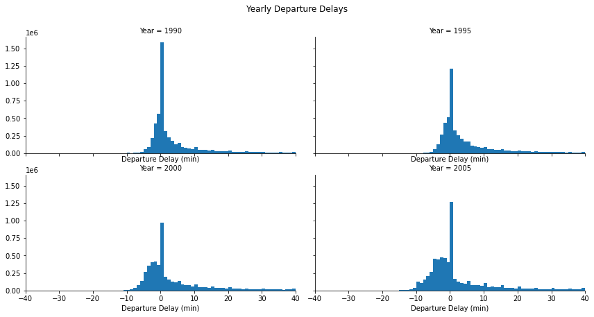

```python
bins_zoomed=np.arange(-40,40+1,1)
g= sb.FacetGrid(data= df, col= 'Year', col_wrap= 2, aspect=2, xlim=(-40,40))
g.map(plt.hist, 'DepDelay', bins=bins_zoomed)
g.fig.suptitle('Yearly Departure Delays',y=1.05)
g.set(xlabel='Departure Delay (min)');
```

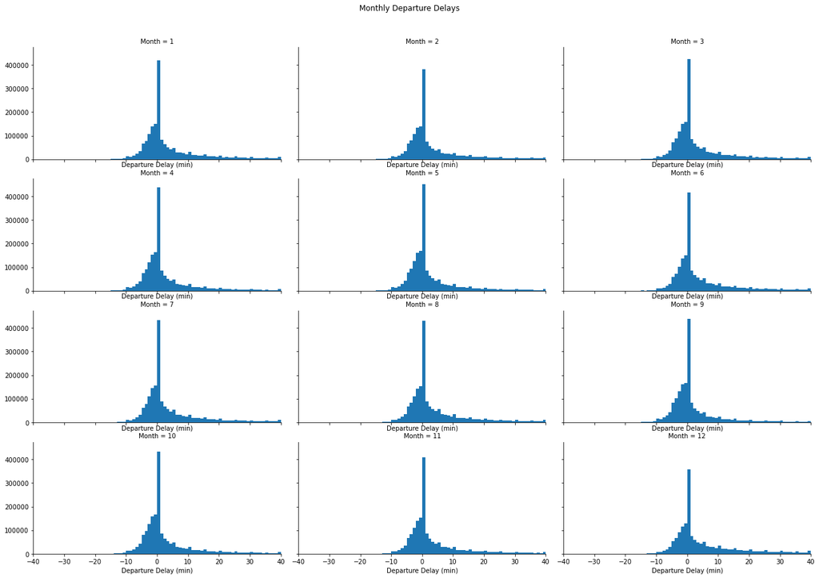

```python
bins_zoomed=np.arange(-40,40+1,1)
g= sb.FacetGrid(data= df, col= 'Month', col_wrap= 3, aspect=2, xlim=(-40,40))
g.map(plt.hist, 'DepDelay', bins=bins_zoomed)
g.fig.suptitle('Monthly Departure Delays',y=1.05)
g.set(xlabel='Departure Delay (min)');
```

### Arrival Delay vs. Departure Delay:

Aside from the outliers, we can see a strong positive relation between the two variables. We can almost see the regression line drawn by overplotting scatter points.

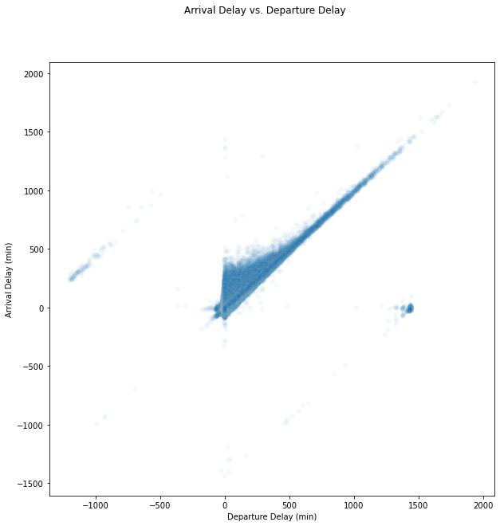

```python
plt.figure(figsize=(10,10))
plt.suptitle('Arrival Delay vs. Departure Delay')
sb.scatterplot(data=df, x='DepDelay', y='ArrDelay', alpha= 1/20)
plt.xlabel('Departure Delay (min)')
plt.ylabel('Arrival Delay (min)');
```

### Carrier Delay Percentage:

| Carrier | Rank by Flights Count | Rank by Delay Percentage |
| --- | --- | --- |
| DL | 1 | 1 |
| WN | 2 | 12 |
| US | 3 | 4 |
| AA | 4 | 7 |
| UA | 5 | 2 |
| NW | 6 | 13 |
| CO | 7 | 9 |

#### Observations:

1. DL Airlines ranked top in both classes. This could be that typical behaviour of a giant relying on heritage, reputation and not seeing the slippery road ahead.
2. WN Airlines has a very interesting performance. While ranking second in number of flights, they managed to rank themselves twelveth in percent delays. Thumbs Up!
3. UA Airlines is on the other end of the spectrum. They rank fifth in top operators (average big player), but they ranked second in percent delays. These guys can need some consultations to their operations.

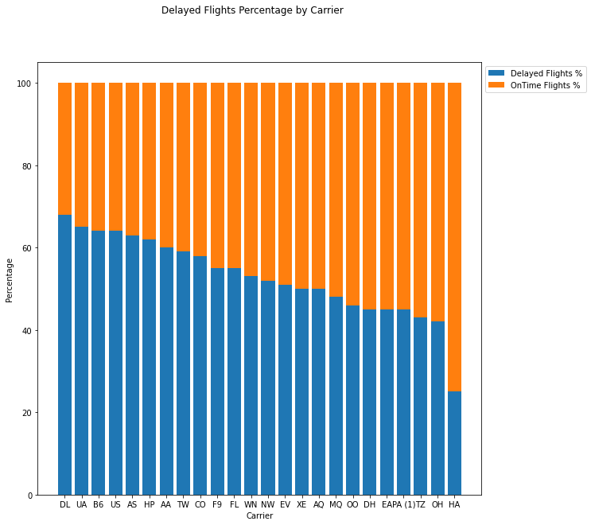

```python
x1=df.groupby('UniqueCarrier').size().reset_index().rename(columns={0:'Total_Flights'})
x2=df[(df['DepDelay']>0)|(df['ArrDelay']>0)].groupby('UniqueCarrier').size().reset_index().rename(columns={0:'Delayed'})
df_carrier_delay=x1.merge(x2,on='UniqueCarrier')
df_carrier_delay['Delay_Percent']= 100* df_carrier_delay['Delayed']/df_carrier_delay['Total_Flights']
df_carrier_delay['Delay_Percent']=df_carrier_delay['Delay_Percent'].astype(int)
df_carrier_delay['OnTime_Percent']= 100-df_carrier_delay['Delay_Percent']
df_carrier_delay.sort_values(by='Delay_Percent',ascending=False, inplace=True)
df_carrier_delay.head(5)

plt.figure(figsize=(10,10))
plt.suptitle('Delayed Flights Percentage by Carrier')
plt.bar(x=df_carrier_delay['UniqueCarrier'],height=df_carrier_delay['Delay_Percent'],label='Delayed Flights %')
plt.bar(x=df_carrier_delay['UniqueCarrier'],height=df_carrier_delay['OnTime_Percent'],
        bottom=df_carrier_delay['Delay_Percent'], label='OnTime Flights %')
plt.xlabel('Carrier')
plt.ylabel('Percentage')
plt.legend(bbox_to_anchor=(1,1));
```

### Airports' Delays:

1. We can see that there are three airports that are considered busily (more than 1 million flights) both based on inbound and inbound/outbound combinations. Interestingly these three airports are absent from the top delaying airports (with average delays of more than 15 minutes). You should be lucky to have your flight departing from ATL, ORD or DFW airports.
2. We also notice that there are 4 airports with a negative average delay. These airports may have spectacular operation or they are of small size with small number of flights.

This point onwards, we will examine only departure delays. Arrival delays in context of this data is a measure of how long the flight took beyond its schedule. As such, arrival operation optimization such as availability of shuttle busses, luggage belts..etc cannot be explained by this dataset. In this regards, we can only attibute an airport to a departure delay. Airports with better operations (more checkin counters, faster security scans..etc) will tend to minimize departure delays. This is further evident statistically by the strong corellation between departure delay and arrival delay decpicted earlier.

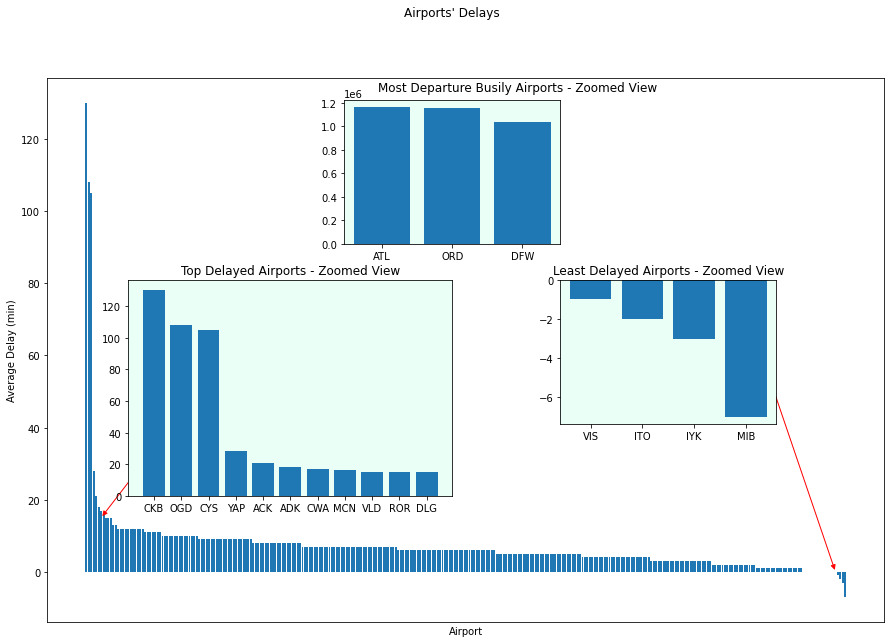

```python
Airport_Delays = (df.groupby(['Origin'])['DepDelay'].mean()).reset_index().rename(columns={'DepDelay':'Avg_Delay'})
Airport_Delays['Avg_Delay']=Airport_Delays['Avg_Delay'].astype(int)
Airport_Delays.sort_values(by='Avg_Delay', ascending=False, inplace=True)

plt.figure(figsize=(15,10))
plt.suptitle('Airports\' Delays')

plt.bar(x=Airport_Delays['Origin'], height=Airport_Delays['Avg_Delay'])
plt.ylabel('Average Delay (min)')
plt.xlabel('Airport')
plt.xticks([]);

zoom_df = Airport_Delays[Airport_Delays['Avg_Delay']>=15]
zoom_df2 = Airport_Delays[Airport_Delays['Avg_Delay']<0]
zoom_df3 = flights_airports[flights_airports['Direction']=='Origin'].value_counts().reset_index().rename(columns={0:'Num'})
zoom_df3 = zoom_df3[zoom_df3['Num']>=1e6]

plt.annotate("", xy=(6, 15), xytext=(40, 45),arrowprops=dict(arrowstyle="-|>",color='r',ls='-'))
plt.annotate("", xy=(305, 0), xytext=(270, 70),arrowprops=dict(arrowstyle="-|>",color='r',ls='-'))
ax=plt.axes([0.2,0.3,0.3,0.3], facecolor='#eafff5')
ax.bar(x=zoom_df['Origin'],height=zoom_df['Avg_Delay'])
ax.set_title('Top Delayed Airports - Zoomed View')

ax2=plt.axes([0.6,0.4,0.2,0.2], facecolor='#eafff5')
ax2.bar(x=zoom_df2['Origin'],height=zoom_df2['Avg_Delay'])
ax2.set_title('Least Delayed Airports - Zoomed View')

ax3=plt.axes([0.4,0.65,0.2,0.2], facecolor='#eafff5')
ax3.bar(x=zoom_df3['Airport'], height=zoom_df3['Num'])
ax3.set_title('Most Departure Busily Airports - Zoomed View',x=0.8,y=1.02);
```

### Chronological Departure Delay Distribution

The graph further proves the spread of Departure Delay in the negative direction is increasing over time.

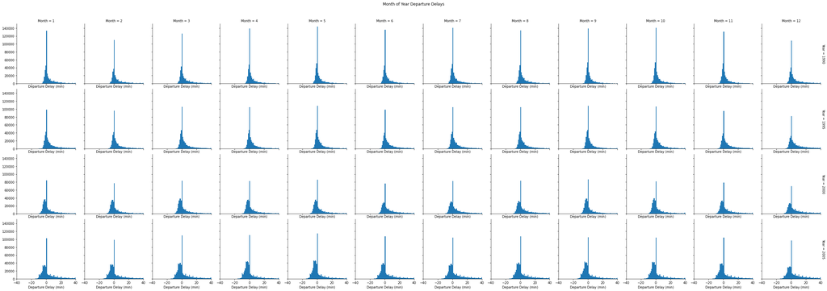

```python
bins_zoomed=np.arange(-40,40+1,1)
g= sb.FacetGrid(data= df, col='Month', row= 'Year', xlim=(-40,40), margin_titles=True)
g.map(plt.hist, 'DepDelay', bins=bins_zoomed)
g.fig.suptitle('Month of Year Departure Delays',y=1.05)
g.set(xlabel='Departure Delay (min)');
```

### Where would you expect the worst delays:

The data shows that the average delays were highest for flights operated by the below airlines from the shown airports.

[output not shown]

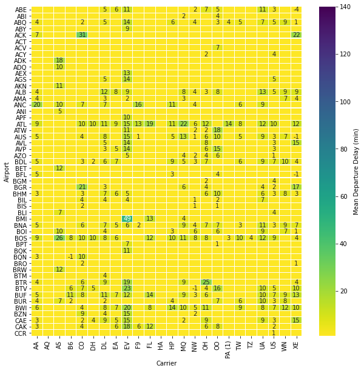

```python
dep_delay_means = df.groupby(['UniqueCarrier', 'Origin']).mean()['DepDelay']
dep_delay_means = dep_delay_means.reset_index(name = 'DepDelay_Avg')
dep_delay_means['DepDelay_Avg'].fillna(-100,inplace=True)
dep_delay_means['DepDelay_Avg']=dep_delay_means['DepDelay_Avg'].astype(int)
dep_delay_means = dep_delay_means.pivot(index = 'Origin', columns = 'UniqueCarrier', values = 'DepDelay_Avg')
labels = dep_delay_means.copy()
for col in labels.columns:
    labels[col]=labels[col].astype(str)
    labels[col].replace('-100','',inplace=True)
    labels[col].replace('0','',inplace=True)

ddm_sliced, labels_sliced=[],[]
j=0
for i in range(6):
    ddm_sliced.append(dep_delay_means.iloc[j:j+52])
    labels_sliced.append(labels.iloc[j:j+52])
    j+=52

plt.figure(figsize=(10,10))
sb.heatmap(ddm_sliced[0], annot=labels_sliced[0], fmt='s', vmin=1, vmax=140, cmap='viridis_r', linewidth=0.1,
           cbar_kws ={'label':'Mean Departure Delay (min)'})
plt.ylabel('Airport')
plt.xlabel('Carrier');
```

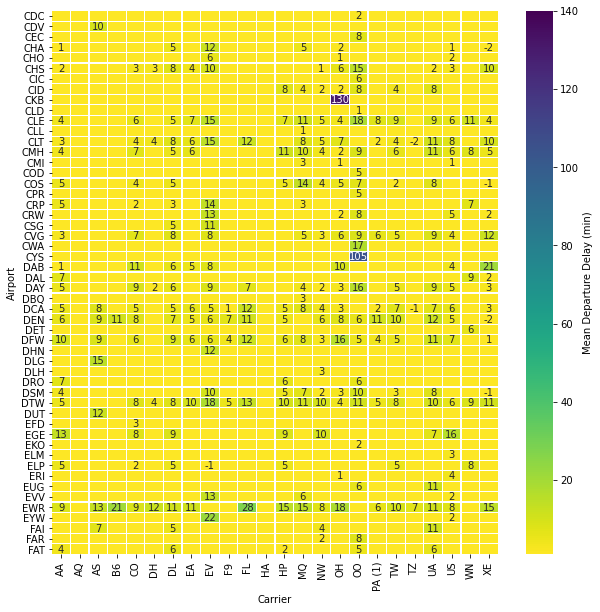

```python
plt.figure(figsize=(10,10))
sb.heatmap(ddm_sliced[1], annot=labels_sliced[1], fmt='s', vmin=1, vmax=140, cmap='viridis_r', linewidth=0.1,
           cbar_kws ={'label':'Mean Departure Delay (min)'})
plt.ylabel('Airport')
plt.xlabel('Carrier');
```

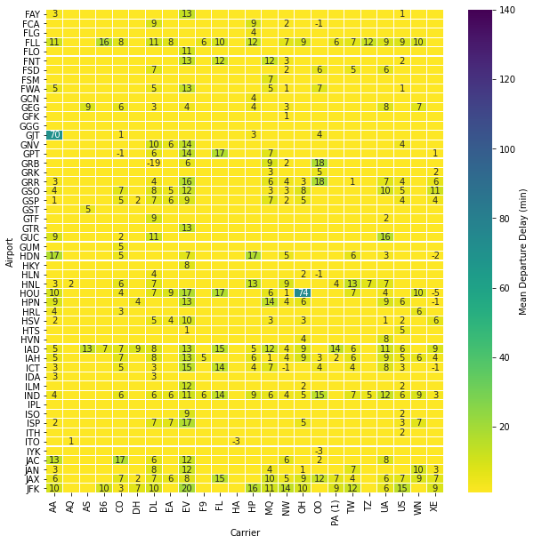

```python
plt.figure(figsize=(10,10))
sb.heatmap(ddm_sliced[2], annot=labels_sliced[2], fmt='s', vmin=1, vmax=140, cmap='viridis_r', linewidth=0.1,
           cbar_kws ={'label':'Mean Departure Delay (min)'})
plt.ylabel('Airport')
plt.xlabel('Carrier');
```

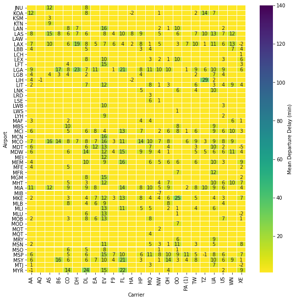

```python
plt.figure(figsize=(10,10))
sb.heatmap(ddm_sliced[3], annot=labels_sliced[3], fmt='s', vmin=1, vmax=140, cmap='viridis_r', linewidth=0.1,
           cbar_kws ={'label':'Mean Departure Delay (min)'})
plt.ylabel('Airport')
plt.xlabel('Carrier');
```

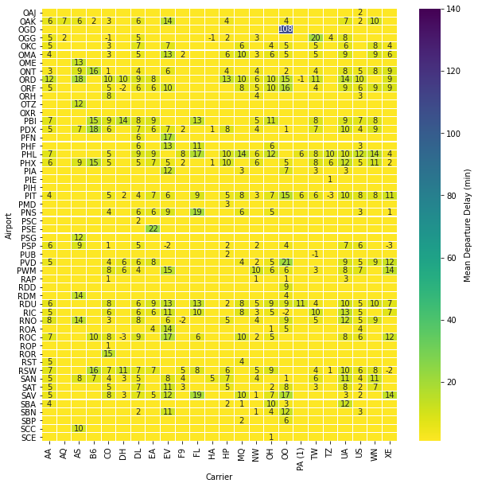

```python
plt.figure(figsize=(10,10))
sb.heatmap(ddm_sliced[4], annot=labels_sliced[4], fmt='s', vmin=1, vmax=140, cmap='viridis_r', linewidth=0.1,
           cbar_kws ={'label':'Mean Departure Delay (min)'})
plt.ylabel('Airport')
plt.xlabel('Carrier');
```

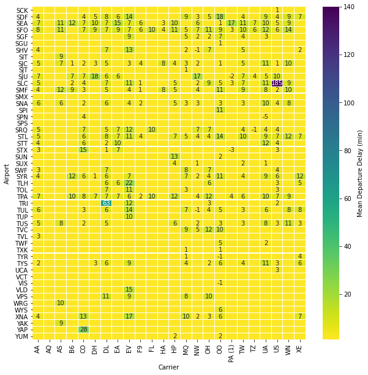

```python
plt.figure(figsize=(10,10))
sb.heatmap(ddm_sliced[5], annot=labels_sliced[5], fmt='s', vmin=1, vmax=140, cmap='viridis_r', linewidth=0.1,
           cbar_kws ={'label':'Mean Departure Delay (min)'})
plt.ylabel('Airport')
plt.xlabel('Carrier');
```